# Regression Project_SajjadRezvani

# 9. Identifying influential points , 2 predictors and 50 observations (k= 2, n=50)

## 9.1 Finding High leverage Points using Hat-matrix method

```r
# hat values
hv <- hatvalues(mlr_bid)
k= 2
n=50
which(hv > (2*(k+1)/n))
```

```
 2  5  9 43
 2  5  9 43
```

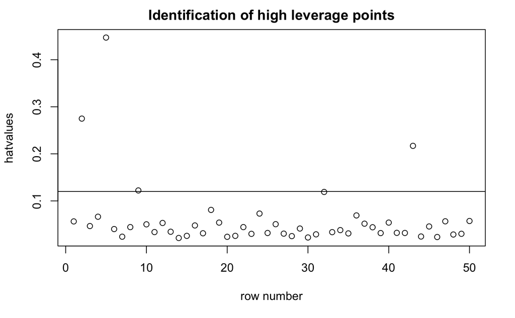

```r
row_num <- c(1:n)
plot(row_num, hv, xlab = "row number",
     ylab = "hatvalues",
     main = "Identification of high leverage points")
abline(h = (2*(k+1)/n))
```

## 9.2 Finding Outliers using externally standardized residuals method

```r
# Use externally standardized residuals (rstudent)
r2 <- rstudent(mlr_bid)
which(abs(r2) > 3)
```

```
5 9
5 9
```

```r
row_num <- c(1:n)
plot(c(1,n), c(-6, 6), xlab = "row number",
     ylab = "externally studentized residuals",
     main = "Identification of outlier points",
     type = "n")
points(row_num, r2)
```

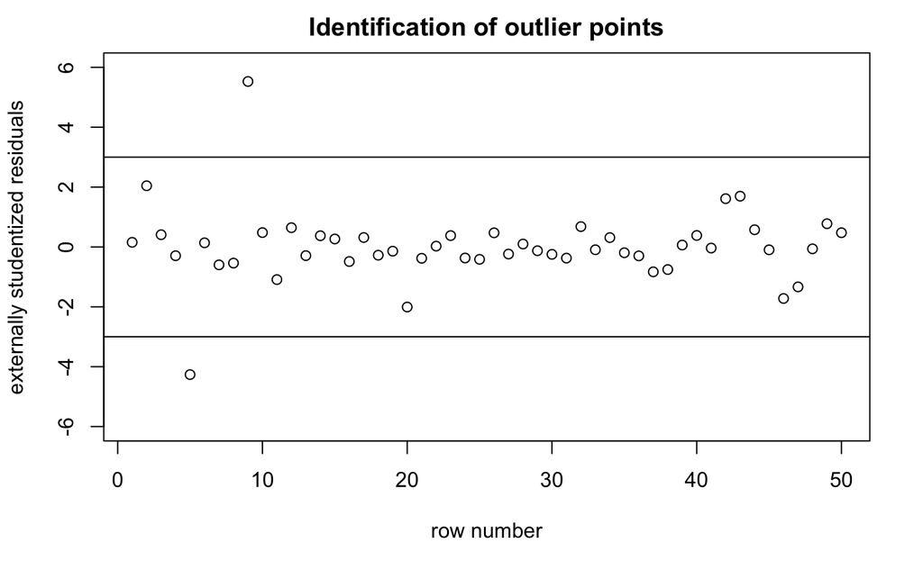

```r
abline(h = 3)
abline(h = -3)
```

## 9.3 Finding Outliers using COVRATIO method

```r
# cov ratio
cv <- covratio(mlr_bid) #influential if covratio > 1 + 3*(k+1)/n OR covratio < 1 - 3*(k+1)/n
which(cv > (1 + 3*(k+1)/n))
```

```
named integer(0)
```

```r
which(cv < (1 - 3*(k+1)/n))
```

```
5 9
5 9
```

```r
row_num <- c(1:n)
plot(row_num, cv, xlab = "row number",
     ylab = "covratio",
     main = "Identification of influential points")
abline(h = (1 + 3*(k+1)/n))
```

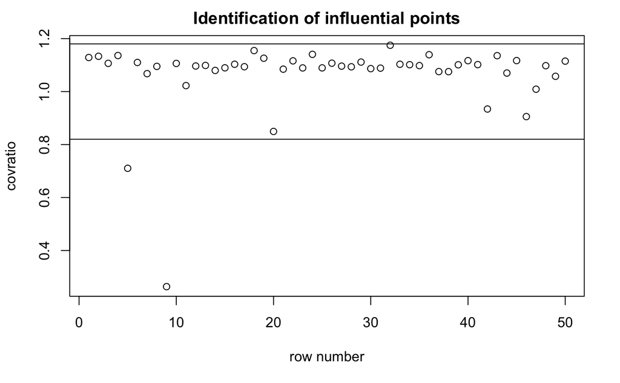

```r
abline(h = (1 - 3*(k+1)/n))
```

```r
NA
NA
```

## 9.4 Finding Outliers using difference in fits method

```r
dffits(mlr_bid) #influential if abs(dffits) > 2*sqrt((k+2)/(n-k-2))
```

```
           1            2            3            4            5            6            7            8
 0.037736916  1.258610687  0.090376401 -0.077981488 -3.833908051  0.028257414 -0.093607908 -0.116089233
           9           10           11           12           13           14           15           16
 2.062611485  0.110391531 -0.203802424  0.152411343 -0.054611688  0.055205602  0.043302023 -0.108951497
          17           18           19           20           21           22           23           24
 0.056619843 -0.081794494 -0.033644594 -0.312619111 -0.061534245  0.005964061  0.066781611 -0.103618683
          25           26           27           28           29           30           31           32
-0.075062760  0.108871579 -0.041972964  0.015630447 -0.026237722 -0.037307474 -0.064245532  0.249811792
          33           34           35           36           37           38           39           40
-0.017445912  0.062219451 -0.034550094 -0.081287480 -0.193855194 -0.161877933  0.011637144  0.091612474
          41           42           43           44           45           46           47           48
-0.006727169  0.292537819  0.892737538  0.090781402 -0.020947334 -0.265579055 -0.326818169 -0.010709740
          49           50
 0.136715883  0.117187666
```

```r
which(abs(dffits(mlr_bid)) > (2*sqrt((k+2)/(n-k-2)))) #
```

```
 2  5  9 43
 2  5  9 43
```

## 8.5 Finding Outliers using Cook’s distance method

```r
# Cook's distance method
cooks.distance(mlr_bid) #influential if d > 1
```

```
           1            2            3            4            5            6            7            8
4.847600e-04 4.945854e-01 2.771740e-03 2.067259e-03 3.588199e+00 2.718338e-04 2.961296e-03 4.561073e-03
           9           10           11           12           13           14           15           16
8.706092e-01 4.129698e-03 1.378980e-02 7.840791e-03 1.013915e-03 1.034804e-03 6.376238e-04 4.022162e-03
          17           18           19           20           21           22           23           24
1.089477e-03 2.274834e-03 3.853557e-04 3.060654e-02 1.285583e-03 1.211423e-05 1.514164e-03 3.645956e-03
          25           26           27           28           29           30           31           32
1.911844e-03 4.017444e-03 5.992782e-04 8.319023e-05 2.343798e-04 4.734069e-04 1.401518e-03 2.104287e-02
          33           34           35           36           37           38           39           40
1.036391e-04 1.315663e-03 4.062228e-04 2.246089e-03 1.260961e-02 8.815480e-03 4.611821e-05 2.849314e-03
          41           42           43           44           45           46           47           48
1.541241e-05 2.758650e-02 2.554623e-01 2.786784e-03 1.494135e-04 2.256859e-02 3.502275e-02 3.906068e-05
          49           50
6.283596e-03 4.654309e-03
```

```r
which(cooks.distance(mlr_bid) > 1) #
```

```
5
5
```

### Using the hat-matrix method to find high leverage points, observations 2, 5, 9 and 43 were found to have high leverage points. Using the externally standardized residuals method to check for outliers, observations 5 and 9 were found to be outliers. Also, using the COVRATIO method showed observation 5 and 9 as being influential, using the difference in fits method showed observations 2, 5, 9 and 43 to be influential and also using the Cook’s distance method showed observation 5 to be influential. After comparing the various influential points, we remove observations 2, 5 and 9 which corresponds to Alaska, California and Florida.We considered these 3 observations as influential points.

# 10. Removing outliers and developing Final mlr model

```r
dat_adj=dat_c3[-c(2,5,9),]
mlr_bid_adj <- lm(Cases ~ Log_summer + Population, data = dat_adj)
summary(mlr_bid_adj)
```

```
Call:
lm(formula = Cases ~ Log_summer + Population, data = dat_adj)

Residuals:
    Min      1Q  Median      3Q     Max
-314385  -52339    7197   71073  271271

Coefficients:
              Estimate Std. Error t value Pr(>|t|)
(Intercept) -4.076e+06  9.709e+05  -4.198 0.000129 ***
Log_summer   2.215e+06  5.267e+05   4.206 0.000126 ***
Population   1.363e-01  3.210e-03  42.459  < 2e-16 ***
---
Signif. codes:  0 ‘***’ 0.001 ‘**’ 0.01 ‘*’ 0.05 ‘.’ 0.1 ‘ ’ 1

Residual standard error: 111400 on 44 degrees of freedom
Multiple R-squared:  0.9791,    Adjusted R-squared:  0.9781
F-statistic:  1029 on 2 and 44 DF,  p-value: < 2.2e-16
```

```r
shapiro.test(mlr_bid_adj$residuals)
```

```
    Shapiro-Wilk normality test

data:  mlr_bid_adj$residuals
W = 0.95177, p-value = 0.05081
```

## This new regression model will satisfy all the linearity assumptions.Adjusted R-square = 0.9781 and **Log_summer** and **Population** are found to be significantly related to the response variable.

## Our model revealed a positive relationship between the two variables (i.e. Logarithm of summer and population) and COVID 19 cases in the USA. This shows that as summer and population increase in a particular state, the number of COVID 19 cases is expected to increase as well.